# HW3

Siming Yan

03 August, 2020

## setup

### 1. Here we explore the maximal margin classifier using the data set listed in the table below, which has 7 observations in 2 dimensions that belong to two classes.

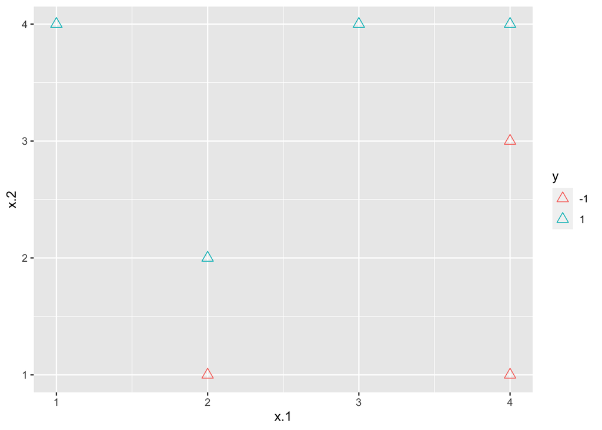

```r
rm(list = ls())
x = matrix(c(3, 2, 4, 1, 2, 4, 4, 4, 2, 4, 4, 1, 3, 1), nrow = 7, ncol = 2)
df <- data.frame(x = x, y = c(1, 1, 1, 1, -1, -1, -1) %>% as.factor())
ggplot(df, aes(x = x.1, y = x.2, color = y)) + geom_point(shape = 2, size = 3)
```

1. (4 pts) Sketch the optimal separating hyperplane in the figure below and provide the equation for this hyperplane in the form of β0 + β1X1 + β2X2 = 0.

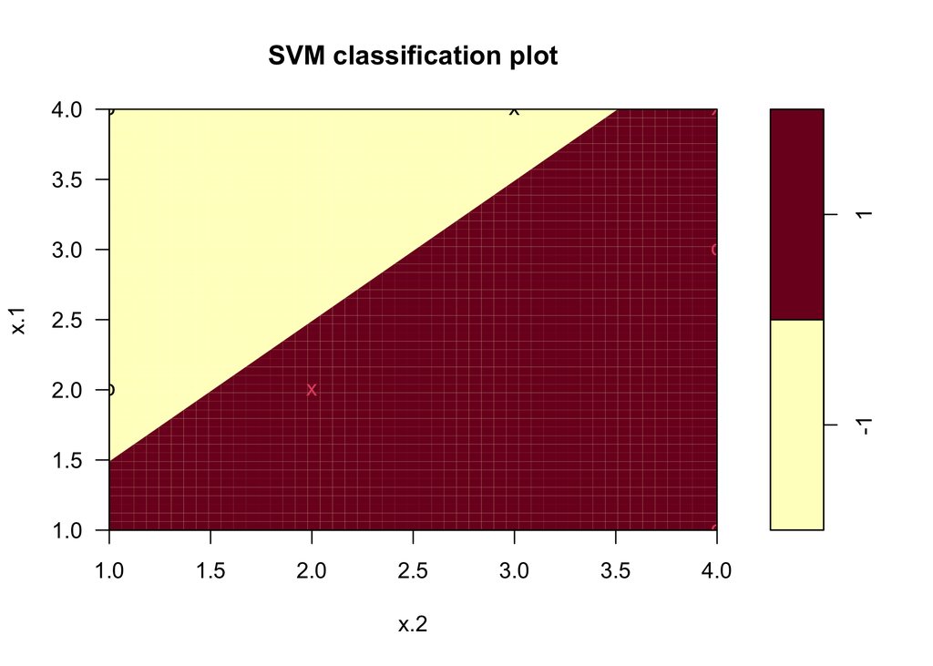

```r
#
sv1 <- svm(y ~ ., data = df, kernel = "linear", cost = 10, scale = FALSE)
sv1 %>% plot(df)
```

```r
sv1 %>% summary
```

```
FALSE
FALSE Call:
FALSE svm(formula = y ~ ., data = df, kernel = "linear", cost = 10, scale = FALSE)
FALSE
FALSE
FALSE Parameters:
FALSE    SVM-Type:  C-classification
FALSE  SVM-Kernel:  linear
FALSE        cost:  10
FALSE
FALSE Number of Support Vectors:  3
FALSE
FALSE  ( 2 1 )
FALSE
FALSE
FALSE Number of Classes:  2
FALSE
FALSE Levels:
FALSE  -1 1
```

```r
#--------------------------------------------
# set.seed(31) tune.out <- tune(svm, y ~ . , data = df, kernel='linear' , ranges
# = list(cost=c(.01, .1 , 1, 10, 100, 1000)), tunecontrol = tune.control(sampling
# = 'cross', cross = 5)) # # #--------------------------------------------
# summary(tune.out) # tune.out$best.model # bestmod <- tune.out$best.model
# summary(bestmod) plot(bestmod, df)
```

*$$-2 \cdot X_1 + 2\cdot X_2 +1 = 0$$*

2. (2 pts) Describe the classification rule for the maximal margin classifier. It should be something along the lines of “Classify to  if · · ·, and classify to △ otherwise.”

3. (2 pts) On the figure, indicate the margin for the maximal margin hyperplance. Calculate the margin. Note that the distance of the point (x0, y0) to the line ax + by + c = 0 is |ax0 +by0 +c|/√a2+b2 .

```r
# beta = drop(t(bestmod$coefs)%*%x[bestmod$index,]) beta0 = bestmod$rho
# intercept1 <- beta0 / beta[1] slope1 <- -beta[2] / beta[1]

#--------------------------------------------

w <- t(sv1$coefs) %*% sv1$SV
beta1 <- -w[2]/w[1]
beta0 = sv1$rho/w[1]

# w <- t(bestmod$coefs) %*% bestmod$SV beta1 <- -w[2]/w[1] beta0 =
# bestmod$rho/w[1] beta
```

$$\begin{eqnarray*}\\
&&β_0 + β_1X1 + β_2X_2 = 0.\\&&
AS: Dis = {|ax_0 + by_0 + c |\over{\sqrt{(a^2+b^2)}}}\\\\&&
Dis = 0.3535534
\end{eqnarray*}$$

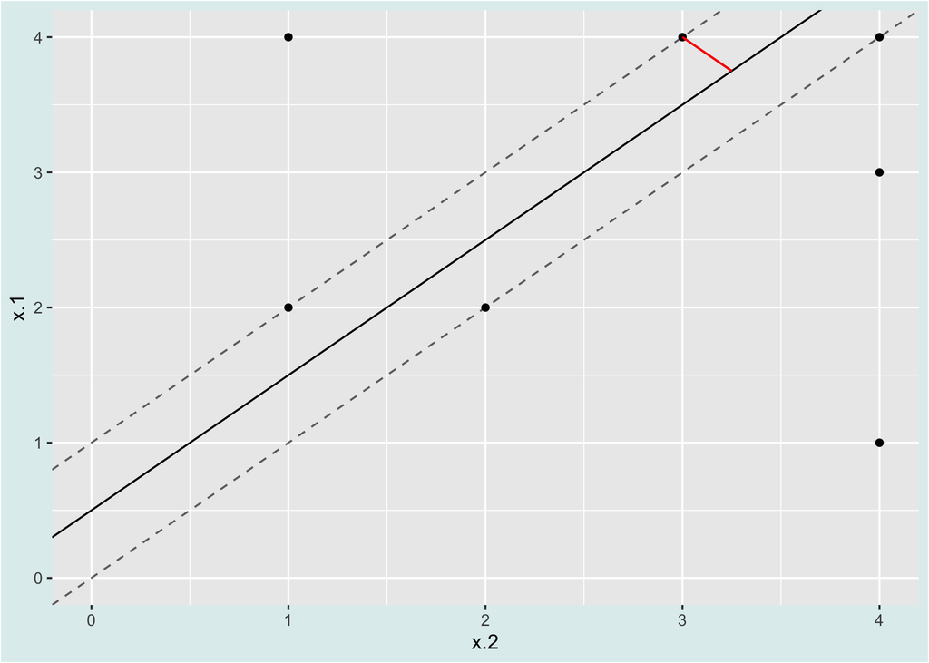

```r
p <- ggplot(data = df) + aes(x = x.2) + geom_point(aes(y = x.1)) + geom_abline(intercept = c(sv1$rho/w[1]),
    slope = beta1) + geom_abline(intercept = (sv1$rho/w[1] + (1/w[1])), slope = beta1,
    linetype = "dashed", alpha = I(0.6)) + geom_abline(intercept = (sv1$rho/w[1] -
    (1/w[1])), slope = beta1, linetype = "dashed", alpha = I(0.6)) + geom_segment(aes(x = 3,
    y = 4), xend = (7.5/2 - 0.5), yend = 7.5/2, color = "#FA0000") + theme(plot.background = element_rect(fill = "azure2"))

p + expand_limits(x = 0, y = 0)
```

```r
# y = -x + 7 y = x+.5
```

4. (2 pts) What are the support vectors for the maximal margin classifier?

### 2. (10 pts) Use the OJ data set, which is part of the ISLR package, to answer the following questions.’

1. Create a training set containing a random sample of 900 observations, and a test set containing the remaining observations.

```r
df <- OJ
# ?OJ
set.seed(1)
train_ind <- sample(seq_len(nrow(df)), size = 900)

train <- df[train_ind, ]
test <- df[-train_ind, ]
```

2. Fit a tree to the training data, with Purchase as the response and the other variables as predictors. Use the summary function to produce summary statistics about the tree, and describe the results obtained. What is the training error rate? How many terminal nodes does the tree have?

```r
tree(Purchase ~ ., train) %>% summary
```

```
Classification tree:
tree(formula = Purchase ~ ., data = train)
Variables actually used in tree construction:
[1] "LoyalCH"       "PriceDiff"     "ListPriceDiff"
Number of terminal nodes:  8
Residual mean deviance:  0.749 = 668 / 892
Misclassification error rate: 0.162 = 146 / 900
```

*Error rate 16.2%. Terminal nodes number is 8.*

3. Type in the name of the tree object in order to get a detailed text output. Pick one of the terminal nodes, and interpret the information displayed.

```r
tree1 <- tree(Purchase ~ ., train)
tree1
```

```
node), split, n, deviance, yval, (yprob)
      * denotes terminal node

 1) root 900 1200 CH ( 0.609 0.391 )
   2) LoyalCH < 0.5036 405  490 MM ( 0.286 0.714 )
     4) LoyalCH < 0.276142 196  150 MM ( 0.128 0.872 )
       8) LoyalCH < 0.0356415 66   10 MM ( 0.015 0.985 ) *
       9) LoyalCH > 0.0356415 130  120 MM ( 0.185 0.815 ) *
     5) LoyalCH > 0.276142 209  290 MM ( 0.435 0.565 )
      10) PriceDiff < 0.05 87   94 MM ( 0.230 0.770 ) *
      11) PriceDiff > 0.05 122  170 CH ( 0.582 0.418 ) *
   3) LoyalCH > 0.5036 495  380 CH ( 0.873 0.127 )
     6) LoyalCH < 0.764572 199  230 CH ( 0.739 0.261 )
      12) PriceDiff < -0.165 35   44 MM ( 0.314 0.686 ) *
      13) PriceDiff > -0.165 164  150 CH ( 0.829 0.171 )
        26) ListPriceDiff < 0.135 27   37 CH ( 0.556 0.444 ) *
        27) ListPriceDiff > 0.135 137   99 CH ( 0.883 0.117 ) *
     7) LoyalCH > 0.764572 296   94 CH ( 0.963 0.037 ) *
```

*For customer loyalty to Citrus Hill orange juice (LoyalCH) below 0.0356415, the number is 66, and they have a larger chance to buy Minute Maid Orange Juice, the prob is 0.985.*

4. Create a plot of the tree, and interpret the results.

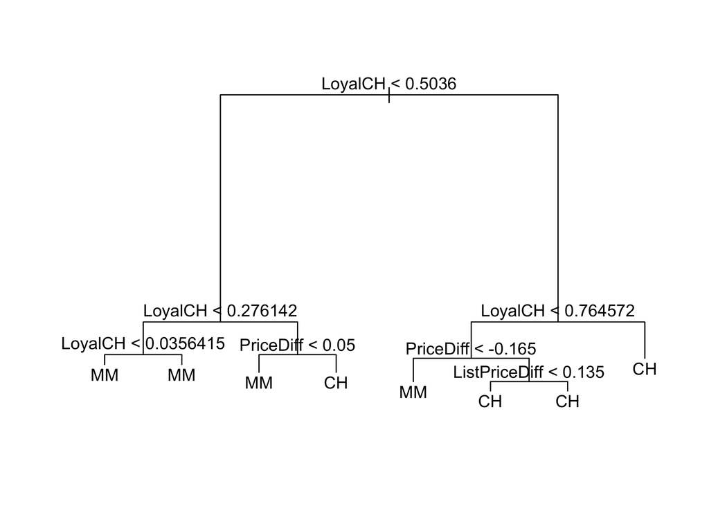

```r
tree(Purchase ~ ., train) %>% plot
tree(Purchase ~ ., train) %>% text(pretty = 0)
```

*The tree shown above mainly divide regarding to the term of “LoyalCH”, there are 8 terminal nodes, we can see when “LoyalCH” is low, people intends to buy MM while “price difference” of two band is no more than 0.05. When “loyalCH” is high, people are more likely to buy CH.*

5. Predict the response on the test data, and produce a confusion matrix comparing the test labels to the predicted test labels. What is the test error rate?

```r
tp1 <- predict(tree1, test, type = "class")

table(tp1, df$Purchase[-train_ind])
```

```
tp1   CH  MM
  CH 100  24
  MM   5  41
```

```r
(6 + 23)/170
```

```
[1] 0.17059
```

*the test error rate is 0.17059*

6. Apply the cv.tree() function to the training set in order to determine the optimal tree size.

```r
set.seed(1)
cvtree <- cv.tree(tree1, FUN = prune.misclass)
cvtree
```

```
$size
[1] 8 6 4 2 1

$dev
[1] 161 160 169 184 352

$k
[1]  -Inf   0.0   6.5  10.0 173.0

$method
[1] "misclass"

attr(,"class")
[1] "prune"         "tree.sequence"
```

```r
which.min(cvtree$dev)
```

```
[1] 2
```

*The tree with 6 terminal nodes leads to lowest Cross-Validation error rate.*

7. Produce a plot with tree size on the x-axis and cross-validated classification error rate on the y-axis.

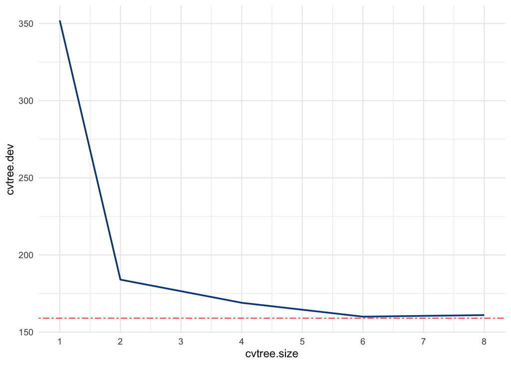

8. Which tree size corresponds to the lowest cross-validated classification error rate?

*The tree with 6 terminal nodes leads to lowest Cross-Validation error rate.*

9. Produce a pruned tree corresponding to the optimal tree size obtained using cross-validation.

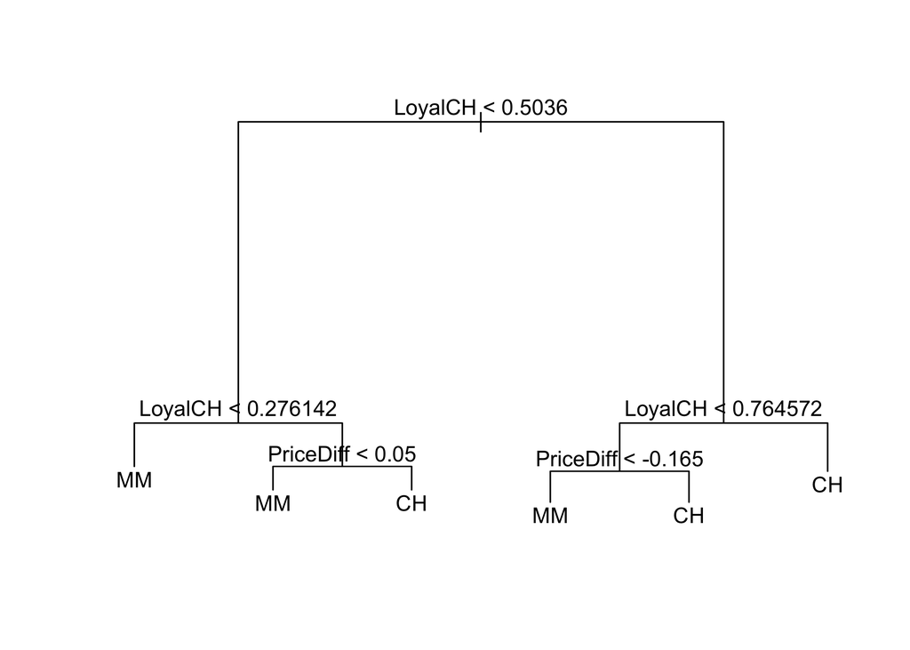

```r
# pick 7
prune_tree <- prune.misclass(tree1, best = 6)
plot(prune_tree)
text(prune_tree, pretty = 0)
```

10. Compare the training error rates between the pruned and unpruned trees. Which is higher?

```r
summary(tree1)$misclass
```

```
[1] 146 900
```

```r
summary(prune_tree)$misclass
```

```
[1] 146 900
```

```r
144/900
```

```
[1] 0.16
```

*All same.*

11. Compare the test error rates between the pruned and unpruned trees. Which is higher?

```r
tp1 <- predict(tree1, test, type = "class")

table(tp1, df$Purchase[-train_ind])
```

```
tp1   CH  MM
  CH 100  24
  MM   5  41
```

```r
(6 + 23)/170
```

```
[1] 0.17059
```

```r
tp2 <- predict(prune_tree, test, type = "class")
table(tp2, df$Purchase[-train_ind])
```

```
tp2   CH  MM
  CH 100  24
  MM   5  41
```

```r
(5 + 24)/170
```

```
[1] 0.17059
```

*The same.*

### 3. (10 pts) Based on the Auto data set, predict whether a given car gets high or low gas mileage.

1. Create a binary variable that takes on a 1 for cars with gas mileage above the median, and a 0 for cars with gas mileage below the median.

```r
df <- mutate(df, above_m = ifelse(df$mpg > median(df$mpg), 1, 0) %>% as.factor())
```

2. Fit a support vector classifier to the data with various values of cost, in order to predict whether a car gets high or low gas mileage. Report the cross-validation errors associated with different values of this parameter. Comment on your results.

```r
set.seed(1)
tune.out <- tune(svm, above_m ~ . - name, data = df, kernel = "linear", ranges = list(cost = c(0.001,
    0.01, 0.1, 1, 5, 10, 100)))

summary(tune.out)$performances
```

```
     cost    error dispersion
1   0.001 0.093333   0.031936
2   0.010 0.088397   0.030508
3   0.100 0.045385   0.035436
4   1.000 0.027692   0.032264
5   5.000 0.010192   0.017868
6  10.000 0.010192   0.017868
7 100.000 0.015192   0.017808
```

```r
bestmod <- tune.out$best.model
bestmod %>% summary
```

[output not shown]

3. Now repeat (2), this time using SVMs with radial and polynomial basis kernels, with different values of gamma and degree and cost. Comment on your results.

```r
tune.out2 <- tune(svm, above_m ~ . - name, data = df, kernel = "radial", ranges = list(cost = c(0.001,
    0.01, 0.1, 1, 5, 10, 100), gamma = c(0.5, 1, 2, 3, 4)))

tune.out2 %>% summary
```

```
Parameter tuning of 'svm':

- sampling method: 10-fold cross validation

- best parameters:
 cost gamma
   10   0.5

- best performance: 0.042756

- Detailed performance results:
      cost gamma    error dispersion
1    0.001   0.5 0.481218   0.046068
2    0.010   0.5 0.481218   0.046068
3    0.100   0.5 0.090641   0.041266
4    1.000   0.5 0.047821   0.021856
5    5.000   0.5 0.045256   0.025741
6   10.000   0.5 0.042756   0.023661
7  100.000   0.5 0.042756   0.023661
8    0.001   1.0 0.481218   0.046068
9    0.010   1.0 0.481218   0.046068
10   0.100   1.0 0.481218   0.046068
11   1.000   1.0 0.065385   0.035975
12   5.000   1.0 0.062885   0.021173
13  10.000   1.0 0.062885   0.021173
14 100.000   1.0 0.062885   0.021173
15   0.001   2.0 0.481218   0.046068
16   0.010   2.0 0.481218   0.046068
17   0.100   2.0 0.481218   0.046068
18   1.000   2.0 0.098141   0.070562
 [ reached 'max' / getOption("max.print") -- omitted 17 rows ]
```

```r
tune.out2$best.model %>% summary
```

```
Call:
best.tune(method = svm, train.x = above_m ~ . - name, data = df,
    ranges = list(cost = c(0.001, 0.01, 0.1, 1, 5, 10, 100), gamma = c(0.5,
        1, 2, 3, 4)), kernel = "radial")


Parameters:
   SVM-Type:  C-classification
 SVM-Kernel:  radial
       cost:  10

Number of Support Vectors:  215

 ( 110 105 )


Number of Classes:  2

Levels:
 0 1
```

*Using radial kernel, the best model obtained when cost = 10, number of Support Vector is 215.*

```r
tune.out3 <- tune(svm, above_m ~ . - name, data = df, kernel = "polynomial", ranges = list(cost = c(0.001,
    0.01, 0.1, 1, 5, 10), gamma = c(0.5, 1, 2, 3, 4), degree = c(1:3)))

tune.out3 %>% summary
```

```
Parameter tuning of 'svm':

- sampling method: 10-fold cross validation

- best parameters:
 cost gamma degree
   10     1      1

- best performance: 0.010192

- Detailed performance results:
     cost gamma degree    error dispersion
1   0.001   0.5      1 0.093526   0.062322
2   0.010   0.5      1 0.090962   0.056411
3   0.100   0.5      1 0.053205   0.042528
4   1.000   0.5      1 0.025321   0.026896
5   5.000   0.5      1 0.012756   0.021750
6  10.000   0.5      1 0.015256   0.017849
7   0.001   1.0      1 0.093397   0.049347
8   0.010   1.0      1 0.085962   0.056505
9   0.100   1.0      1 0.035577   0.040365
10  1.000   1.0      1 0.022885   0.032977
11  5.000   1.0      1 0.015256   0.017849
12 10.000   1.0      1 0.010192   0.017868
13  0.001   2.0      1 0.093397   0.049347
14  0.010   2.0      1 0.075962   0.052629
15  0.100   2.0      1 0.030513   0.035798
 [ reached 'max' / getOption("max.print") -- omitted 75 rows ]
```

```r
tune.out3$best.model %>% summary
```

```
Call:
best.tune(method = svm, train.x = above_m ~ . - name, data = df,
    ranges = list(cost = c(0.001, 0.01, 0.1, 1, 5, 10), gamma = c(0.5,
        1, 2, 3, 4), degree = c(1:3)), kernel = "polynomial")


Parameters:
   SVM-Type:  C-classification
 SVM-Kernel:  polynomial
       cost:  10
     degree:  1
     coef.0:  0

Number of Support Vectors:  26

 ( 12 14 )


Number of Classes:  2

Levels:
 0 1
```

### 4. (10 pts) Use the Boston data set in the MASS package to predict the *median value of owner-occupied homes* (in $1000’s) by training the neural networks. Employ all available predictors in the data, including: (i) crim - per capita crime rate by town, (ii) zn - proportion of residential land zoned for lots over 25,000 sq.ft., (iii) indus - proportion of non-retail business acres per town, (iv) chas - Charles River dummy variable (1 if tract bounds river; 0 otherwise), (v) nox - nitric oxides concentration (parts per 10 million), (vi) RM - average number of rooms per dwelling, (vii) age - proportion of owner-occupied units built prior to 1940, (viii) dis - weighted distances to five Boston employment centers, (ix) rad - index of accessibility to radial highways, (x) tax - full-value property-tax rate per $10,000, (xi) ptratio-pupil-teacher ratio by town, (xii) black - 1000(Bk − 0.63)2 where Bk is the proportion of blacks by town, (xiii) lstat - % lower status of the population.

```r
df <- Boston
```

```r
set.seed(6)
samplesize = 0.75 * nrow(df)
index = sample(nrow(df), size = samplesize)

# Create training and test set
dftrain = df[index, ]
dftest = df[-index, ]

max = apply(df, 2, max)
min = apply(df, 2, min)
scaled = as.data.frame(scale(df, center = min, scale = max - min))

trainNN = scaled[index, ]
testNN = scaled[-index, ]
```

1. When training your network,*vary the number of hidden layer from 1 to 10* but keep the number of *neurons in each layer at 5*. Find the best network that has the *lowest MSE*. Remember to *apply min-max scale to the data before fitting the network*. Also split the data to 75% training and 25% test data.

```r
for (i in 1:10) {
    NN1[[i]] = list(5 %>% rep(i))
}

for (i in 1:10) {
    set.seed(13)
    samplesize = 0.75 * nrow(df)
    index = sample(nrow(df), size = samplesize)
    trainNN = scaled[index, ]
    testNN = scaled[-index, ]
    dftest = df[-index, ]
    # --------------------------------------------

    NN <- neuralnet(medv ~ ., trainNN, hidden = NN1[[i]][[1]] %>% as.numeric(), linear.output = T)
    predict_nn <- compute(NN, testNN[, c(1:13)])
    predict_nn = (predict_nn$net.result * (max(df$medv) - min(df$medv))) + min(df$medv)
    RMSE.NN[i] <- (sum((dftest$medv - predict_nn)^2)/nrow(dftest))^0.5
}

which.min(RMSE.NN)
```

```
FALSE [1] 9
```

```r
# -------------------------------------------- plot(NN)
```

2. Do 10-fold cross validation on the network determined in (1) and report the mean CV error.

```r
library(plyr)
```

```r
i = which.min(RMSE.NN)[1]

NN <- neuralnet(medv ~ ., trainNN, hidden = NN1[[i]][[1]] %>% as.numeric(), linear.output = T)
```

```r
set.seed(450)
cv.error <- NULL
k <- 10


# pbar <- create_progress_bar('text') pbar$init(k)

for (i in 1:k) {
    set.seed(13)
    samplesize = 0.75 * nrow(df)
    index = sample(nrow(df), size = samplesize)
    trainNN = scaled[index, ]
    testNN = scaled[-index, ]
    dftest = df[-index, ]
    #
    NN <- neuralnet(medv ~ ., trainNN, hidden = NN1[[i]][[1]] %>% as.numeric(), linear.output = T)

    pr.nn <- compute(NN, testNN[, 1:13])
    pr.nn <- pr.nn$net.result * (max(df$medv) - min(df$medv)) + min(df$medv)

    test.cv.r <- (testNN$medv) * (max(df$medv) - min(df$medv)) + min(df$medv)

    cv.error[i] <- sum((test.cv.r - pr.nn)^2)/nrow(testNN)

    # pbar$step()
}
```

```r
cv.error %>% data.frame %>% transpose() %>% kbt
```

| V1 | V2 | V3 | V4 | V5 | V6 | V7 | V8 | V9 | V10 |
| --- | --- | --- | --- | --- | --- | --- | --- | --- | --- |
| 58.53 | 37.576 | 23.228 | 12.93 | 13.117 | 20.108 | 14.205 | 12.166 | 10.105 | 13.58 |

```r
mean(cv.error)
```

```
[1] 21.554
```

*mean cv.error :21.554*